# Geopandas 3

All in on spatial overlay operation

```python
import geopandas as gpd
import matplotlib.pyplot as plt
%matplotlib inline
```

**ToC**

- Spatial overlays
  - Point in polygon problem
  - Topology inspections
  - Spatial joins
  - Spatial intersections
    - Save to disk as GeoJSON
- Aggregation using attributes

## Spatial overlays

Spatial overlays is the process of overlaying two or more layers on top of each other and performing operations based on how they overlay

### Point in polygon problem

`Geopandas` is capable of higher level spatial overlay operations, but we can use `shapely` to perform low level geometry `predicate` operations as below:

```python
from shapely.geometry import Point, Polygon

p1 = Point(24.952242, 60.1696017)
p2 = Point(24.976567, 60.1612500)

# Create a Polygon
coords = [(24.950899, 60.169158), (24.953492, 60.169158), (24.953510, 60.170104), (24.950958, 60.169990)]
poly1 = Polygon(coords)
```

```python
gdf_points = gpd.GeoDataFrame(geometry=[p1,p2])
gdf_poly = gpd.GeoDataFrame(geometry=[poly1])
```

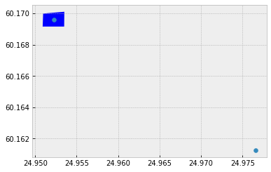

```python
fig, ax1 = plt.subplots()
gdf_poly.plot(ax=ax1)
gdf_points.plot(ax = ax1)
```

Use the `within()` and `contains()` spatial topology operators

```python
p1.within(poly1)
```

```
True
```

```python
p2.within(poly1)
```

```
False
```

```python
poly1.contains(p1)
```

```
True
```

### Topology inspections

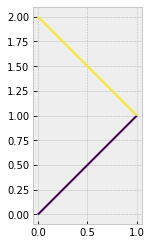

```python
from shapely.geometry import LineString, MultiLineString

line_a = LineString([(0, 0), (1, 1)])
line_b = LineString([(1, 1), (0, 2)])

gdf_lines = gpd.GeoDataFrame(geometry=[line_a, line_b])
gdf_lines.plot(cmap='viridis')
```

```python
line_a.touches(line_b)
```

```
True
```

```python
line_a.intersects(line_b)
```

```
True
```

### Spatial joins

the `sjoin()` is a powerful method. Internally it does the overlay operations and performs a **spatial join**.

```python
geocoded_address = gpd.read_file('./data/addresses_geocoded_3879.shp')
pop_poly = gpd.read_file('./data/population_grid/Vaestotietoruudukko_2015.shp')
```

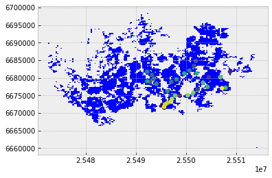

```python
fig3, ax3 = plt.subplots(1)
pop_poly.plot(ax=ax3)
geocoded_address.plot(ax=ax3, cmap = 'viridis')
```

Above you can see the polygons and the geocoded address points. Lets plot their dataframes to see the columns

```python
geocoded_address.head()
```

|  | address | geometry |
| --- | --- | --- |
| 0 | Itämerenkatu 14, 00180, Helsinki | POINT (25495255.82235641 6672275.260963614) |
| 1 | Kampinkuja 1, 00100, Helsinki | POINT (25496127.70873243 6672843.287593854) |
| 2 | Kaivokatu 8, 00100, Helsinki | POINT (25496750.13674767 6673047.518228112) |
| 3 | Hermanstads strandväg 1, 00580, Helsingfors | POINT (25498747.0563857 6674958.07898162) |
| 4 | Itäväylä 900, 00890, Helsinki | POINT (25508815.55214499 6681781.436864837) |

```python
pop_poly.head()
```

|  | INDEX | ASUKKAITA | ASVALJYYS | IKA0_9 | IKA10_19 | IKA20_29 | IKA30_39 | IKA40_49 | IKA50_59 | IKA60_69 | IKA70_79 | IKA_YLI80 | geometry |
| --- | --- | --- | --- | --- | --- | --- | --- | --- | --- | --- | --- | --- | --- |
| 0 | 688 | 8 | 31.0 | 99 | 99 | 99 | 99 | 99 | 99 | 99 | 99 | 99 | POLYGON ((25472499.99532626 6689749.005069185,... |
| 1 | 703 | 6 | 42.0 | 99 | 99 | 99 | 99 | 99 | 99 | 99 | 99 | 99 | POLYGON ((25472499.99532626 6685998.998064222,... |
| 2 | 710 | 8 | 44.0 | 99 | 99 | 99 | 99 | 99 | 99 | 99 | 99 | 99 | POLYGON ((25472499.99532626 6684249.004130407,... |
| 3 | 711 | 7 | 64.0 | 99 | 99 | 99 | 99 | 99 | 99 | 99 | 99 | 99 | POLYGON ((25472499.99532626 6683999.004997005,... |
| 4 | 715 | 19 | 23.0 | 99 | 99 | 99 | 99 | 99 | 99 | 99 | 99 | 99 | POLYGON ((25472499.99532626 6682998.998461431,... |

Rename a column

```python
pop_poly.rename(columns={'ASUKKAITA':'pop15'}, inplace=True)
pop_poly.columns
```

```
Index(['INDEX', 'pop15', 'ASVALJYYS', 'IKA0_9', 'IKA10_19', 'IKA20_29',
       'IKA30_39', 'IKA40_49', 'IKA50_59', 'IKA60_69', 'IKA70_79', 'IKA_YLI80',
       'geometry'],
      dtype='object')
```

Filter and retain just the columns that are necessary. Then assert the CRS is same before doing spatial join

```python
pop_poly_filtered = pop_poly[['pop15', 'geometry']]
pop_poly_filtered.crs == geocoded_address.crs
```

```
True
```

You specify the `spatial operation` when doing a join. Here the topology looks for `within`.

```python
geocoded_address_joined = gpd.sjoin(left_df=geocoded_address,
                                   right_df=pop_poly_filtered,
                                   how="inner", op='within')
geocoded_address_joined.head()
```

|  | address | geometry | index_right | pop15 |
| --- | --- | --- | --- | --- |
| 0 | Itämerenkatu 14, 00180, Helsinki | POINT (25495255.82235641 6672275.260963614) | 3214 | 521 |
| 1 | Kampinkuja 1, 00100, Helsinki | POINT (25496127.70873243 6672843.287593854) | 3326 | 173 |
| 2 | Kaivokatu 8, 00100, Helsinki | POINT (25496750.13674767 6673047.518228112) | 3449 | 31 |
| 11 | Rautatientori 1, 00100, Helsinki | POINT (25496939.39933316 6673189.887604699) | 3449 | 31 |
| 4 | Itäväylä 900, 00890, Helsinki | POINT (25508815.55214499 6681781.436864837) | 5680 | 28 |

```python
geocoded_address_joined.to_file('./data/address_geocoded_joined.shp')
```

Plot the data using classed colored renderer, based on the population column

```
Text(0.5,1,"Number of people living in the address' district")
```

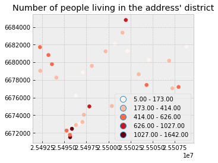

```python
geocoded_address_joined.plot(column='pop15', cmap='Reds',
                            scheme='fisher_jenks', legend=True)
plt.title("Number of people living in the address' district")
```

## Spatial intersections

So far we saw how to join features based on their location, below we see how to intersect two layers and create new geometries.

Spatial joins preserve geometry and only get attributes. However, intersections and unions will create new (often smaller) geometries that include the characteristics of both the layers.

```python
borders_gdf = gpd.read_file('./data/helsinki_borders/Helsinki_borders.shp')
travel_grid_gdf = gpd.read_file('./data/travel_times/TravelTimes_to_5975375_RailwayStation.shp')

borders_gdf.head(3)
```

|  | GML_ID | NAMEFIN | NAMESWE | NATCODE | geometry |
| --- | --- | --- | --- | --- | --- |
| 0 | 27517366 | Helsinki | Helsingfors | 091 | POLYGON ((399936.363 6684600.244, 399937.63 66... |

```python
travel_grid_gdf.head(3)
```

|  | car_m_d | car_m_t | car_r_d | car_r_t | from_id | pt_m_d | pt_m_t | pt_m_tt | pt_r_d | pt_r_t | pt_r_tt | to_id | walk_d | walk_t | geometry |
| --- | --- | --- | --- | --- | --- | --- | --- | --- | --- | --- | --- | --- | --- | --- | --- |
| 0 | 32297 | 43 | 32260 | 48 | 5785640 | 32616 | 116 | 147 | 32616 | 108 | 139 | 5975375 | 32164 | 459 | POLYGON ((382000.0001358641 6697750.000038058,... |
| 1 | 32508 | 43 | 32471 | 49 | 5785641 | 32822 | 119 | 145 | 32822 | 111 | 133 | 5975375 | 29547 | 422 | POLYGON ((382250.0001358146 6697750.000038053,... |
| 2 | 30133 | 50 | 31872 | 56 | 5785642 | 32940 | 121 | 146 | 32940 | 113 | 133 | 5975375 | 29626 | 423 | POLYGON ((382500.0001357661 6697750.000038046,... |

```python
travel_grid_gdf.shape
```

```
(13231, 15)
```

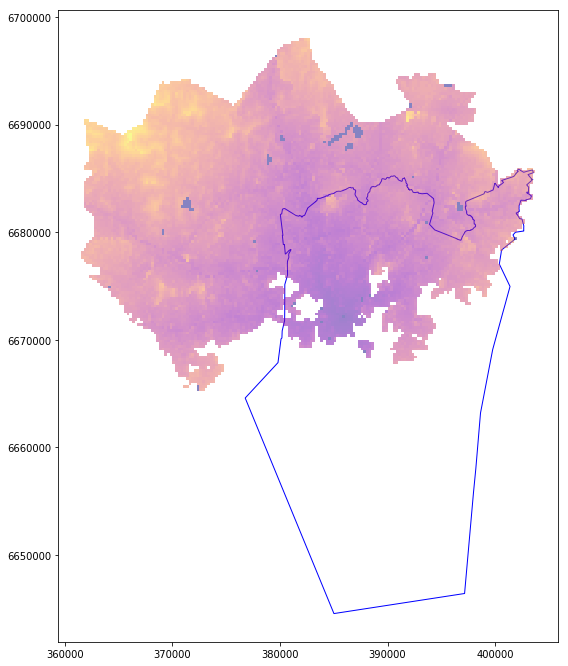

```python
# plot the boundary as basemap layer
basemap_ax = borders_gdf.plot(color='white', edgecolor='blue', figsize=(8, 12))

# do a class colored renderer on travel time by car column
travel_grid_gdf.plot(ax = basemap_ax, column='car_r_t',
                     alpha=0.5, cmap='plasma')

plt.tight_layout()
```

The city of Helsinki is to the south. Thus we see the travel times increasing as we fan out. Now let us intersect the travel grid with basemap layer and select only the polygons that **intersect**

```python
%%time
intersect_result = gpd.overlay(travel_grid_gdf, borders_gdf, how='intersection')
```

```
CPU times: user 1min 18s, sys: 318 ms, total: 1min 18s
Wall time: 1min 19s
```

This is an expensive operations and is time consuming.

```python
intersect_result.head(4)
```

|  | car_m_d | car_m_t | car_r_d | car_r_t | from_id | pt_m_d | pt_m_t | pt_m_tt | pt_r_d | pt_r_t | pt_r_tt | to_id | walk_d | walk_t | GML_ID | NAMEFIN | NAMESWE | NATCODE | geometry |
| --- | --- | --- | --- | --- | --- | --- | --- | --- | --- | --- | --- | --- | --- | --- | --- | --- | --- | --- | --- |
| 0 | 15981 | 36 | 15988 | 41 | 6002702 | 14698 | 65 | 73 | 14698 | 61 | 72 | 5975375 | 14456 | 207 | 27517366 | Helsinki | Helsingfors | 091 | POLYGON ((391000.0001349226 6667750.00004299, ... |
| 1 | 16190 | 34 | 16197 | 39 | 6002701 | 14661 | 64 | 73 | 14661 | 60 | 72 | 5975375 | 14419 | 206 | 27517366 | Helsinki | Helsingfors | 091 | POLYGON ((390750.0001349644 6668000.000042951,... |
| 2 | 15727 | 33 | 15733 | 37 | 6001132 | 14256 | 59 | 69 | 14256 | 55 | 62 | 5975375 | 14014 | 200 | 27517366 | Helsinki | Helsingfors | 091 | POLYGON ((391000.0001349143 6668000.000042943,... |
| 3 | 15975 | 33 | 15982 | 37 | 6001131 | 14512 | 62 | 73 | 14512 | 58 | 70 | 5975375 | 14270 | 204 | 27517366 | Helsinki | Helsingfors | 091 | POLYGON ((390750.0001349644 6668000.000042951,... |

```python
intersect_result.shape
```

```
(3836, 19)
```

Thus the number of records / polygons has reduced from around `13,000` to around `3800`. Let us plot this to visualize the result

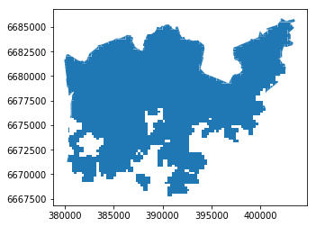

```python
intersect_result.plot()
```

### Save as GeoJSON

The shape is similar to the shaded polygon in the previous plot. Let us save it to disk as a **GeoJSON** for future use.

```python
intersect_result.to_file('./data/travel_times/travel_times_overlay_helsinki.geojson',
                        driver='GeoJSON')
```

## Attribute aggregation

We can use regular pandas expressions to aggregate by attributes. For instance, we can aggregate all neighboring polygons grids that have the same travel time.

```python
intersect_result = gpd.read_file('./data/travel_times/travel_times_overlay_helsinki.geojson')
intersect_result.head(3)
```

|  | car_m_d | car_m_t | car_r_d | car_r_t | from_id | pt_m_d | pt_m_t | pt_m_tt | pt_r_d | pt_r_t | pt_r_tt | to_id | walk_d | walk_t | GML_ID | NAMEFIN | NAMESWE | NATCODE | geometry |
| --- | --- | --- | --- | --- | --- | --- | --- | --- | --- | --- | --- | --- | --- | --- | --- | --- | --- | --- | --- |
| 0 | 15981 | 36 | 15988 | 41 | 6002702 | 14698 | 65 | 73 | 14698 | 61 | 72 | 5975375 | 14456 | 207 | 27517366 | Helsinki | Helsingfors | 091 | POLYGON ((391000.0001349226 6667750.00004299, ... |
| 1 | 16190 | 34 | 16197 | 39 | 6002701 | 14661 | 64 | 73 | 14661 | 60 | 72 | 5975375 | 14419 | 206 | 27517366 | Helsinki | Helsingfors | 091 | POLYGON ((390750.0001349644 6668000.000042951,... |
| 2 | 15727 | 33 | 15733 | 37 | 6001132 | 14256 | 59 | 69 | 14256 | 55 | 62 | 5975375 | 14014 | 200 | 27517366 | Helsinki | Helsingfors | 091 | POLYGON ((391000.0001349143 6668000.000042943,... |

```python
intersect_result['car_r_t'].value_counts()
```

```
 25    194
 26    177
 24    159
 30    155
 29    153
 28    151
 35    149
 23    148
 33    147
 36    145
 27    144
 32    144
 31    142
 34    137
 21    129
```

[output cut: 37 more lines]

```python
result_aggregated = intersect_result.dissolve(by='car_r_t')
result_aggregated.shape
```

```
(51, 18)
```

```python
result_aggregated.head(3)
```

| car_r_t | geometry | car_m_d | car_m_t | car_r_d | from_id | pt_m_d | pt_m_t | pt_m_tt | pt_r_d | pt_r_t | pt_r_tt | to_id | walk_d | walk_t | GML_ID | NAMEFIN | NAMESWE | NATCODE |
| --- | --- | --- | --- | --- | --- | --- | --- | --- | --- | --- | --- | --- | --- | --- | --- | --- | --- | --- |
| -1 | (POLYGON ((388000.0001354737 6669000.000042855... | -1 | -1 | -1 | 5996387 | -1 | -1 | -1 | -1 | -1 | -1 | -1 | -1 | -1 | 27517366 | Helsinki | Helsingfors | 091 |
| 0 | POLYGON ((386000.0001357812 6672000.000042388,... | 0 | 0 | 0 | 5975375 | 0 | 0 | 0 | 0 | 0 | 0 | 5975375 | 0 | 0 | 27517366 | Helsinki | Helsingfors | 091 |
| 7 | POLYGON ((386250.0001357396 6671750.000042424,... | 1059 | 7 | 1059 | 5977007 | 447 | 6 | 6 | 447 | 6 | 6 | 5975375 | 447 | 6 | 27517366 | Helsinki | Helsingfors | 091 |

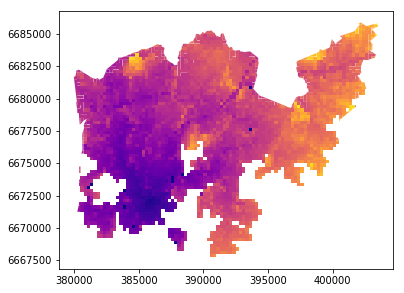

```python
result_aggregated.plot(cmap='plasma', figsize=(6,10), linewidth=0)
```

Thus through aggregation, we have dissolved the number of features from `3800`s to `51`.

```python
result_aggregated.to_file('./data/travel_times/helsinki_aggregated.geojson',
                          driver='GeoJSON')
```